# ggplot2 - 1

Eric C. Anderson

# Intro to ggplot2

### Prerequisites

- To work through the examples you will need a few different packages.
- Please download/install these before coming to class:
  1. install necessary packages:

     ```r
     install.packages(c("ggplot2","lubridate", "plyr", "mosaic", "mosaicData"))
     ```

  2. Pull the most recent version of the rep-res-course repo just before coming to class.

### Goals for this hour:

1. Describe (briefly) `ggplot2`s underlying philosophy and how to work with it.
2. Quickly overview the _geom_s available in `ggplot2`
3. Develop an example plot together
4. Turn you all loose with the `mosaic` package to experiment with different plots

## About ggplot2

### Basics

- A package created by Hadley Wickham in 2005
- Implements Wilkinson’s “grammar of graphics”
- Unified way of thinking about 2-D statistical graphics
- Not entirely easy to learn
  - if you already know R’s base graphics system, it is painful to re-learn a different way of doing things
  - if you don’t already know how to do graphics in R, be glad.
  - regardless it is worth learning ggplot
  - I am not even going to teach R’s base graphics system
- Amazing for quick data exploration and also produces publication quality graphics
- Support for legends etc., considerably better/easier than R base graphics

### What is this grammar of graphics?

- Traditionally, people have referred to plots by *name*
  - i.e., scatterplot, histogram, bar chart, bubble plot, etc.
- Disadvantages:
  - Lots of possible graphics = way too many names
  - Fails to acknowledge the common elements / similarities / dissimilarities between different plots
- Wilkinson’s *Grammar of Graphics* (a book) describes a few building blocks which when assembled together in particular ways can generate all these named graphics (and more)
  - Provides a nice way of thinking about and describing graphics

### ggplot2

- Hadley Wickham’s R implementation of a modified (*layered*) grammar of graphics
- `ggplot` and `ggplot2` are similar. ``ggplot2` is just more recent (and recommended)
- `ggplot` operates on *data frames*
  - in R base graphics typically you pass in vectors
  - in `ggplot` everything you want to use in a graphic must be contained within a data frame
  - Takes getting used to, but ultimately is a good way of thinking about it.

### Components of the grammar of graphics

1. *data* and *aesthetic mappings*
2. *geoms* (geometric objects)
3. *stats* (statistical transformations)
4. *scales*
5. *coords* (coordinate systems)
6. *facets* (a specification of how to break things into smaller subplots)

We will focus on 1, 2 for most of today.

### In a nutshell

Without getting into the complications of scales and coordinate systems here, in a nutshell, is what ggplot does:

- Layers in plots are made by:
  1. mapping *values* in the columns of a data frame to *aesthetics*, which are properties that can visually express differences, for example:
     1. $x$-position
     2. $y$-position
     3. shape (of a plot character, for example)
     4. color
     5. size (of a point, for example)
  2. Portraying those values by drawing a *geometric object* whose appearance and placement in space is dictated by the mapping of values to aesthetics.

## An example, please

Phew! That is a crazy mouthful. Is this really going to help us make pretty plots?

All I can say is you owe it to yourself to persevere — `ggplot2` is really worth the effort!

### A pole vaulting example

- Here is a concrete example: we will investigate the history of pole-vaulting world records
- I grabbed the data by copying them from http://en.wikipedia.org/wiki/Men's_pole_vault_world_record_progression and pasting them into a text file
- Here we make a data frame out of them:

  ```r
  library(lubridate)  # for dealing with dates
  ```

  ```r
  library(ggplot2)
  library(plyr)
  # first off read the data into a data frame
  pv <- read.table("data/mens_pole_vault_raw.txt",
              sep = "\t",
              header = TRUE,
              stringsAsFactors = FALSE
              )

  # and then clean it up:
  pv$Date <- gsub("\\[[0-9]\\]", "", pv$Date)  # remove the footnote refs in the dates
  pv$Date <- mdy(pv$Date)  # convert dates to lubridate
  pv$Record <- as.numeric(gsub(" m.*", "", pv$Record))  # remove the "m" and other stuff from the heights
  names(pv)[names(pv) == "Record"] = "Meters" # change "Record" column to "Meters"
  ```

- Great, what do these look like? Try `View(pv)` if you are following along. Here are the first few rows too:

  ```r
  head(pv)
  ```

  ```
  ##   Meters      Athlete         Nation               Venue       Date X
  ## 1   4.02  Marc Wright  United States     Cambridge, U.S. 1912-06-08 1
  ## 2   4.09   Frank Foss  United States    Antwerp, Belgium 1920-08-20 1
  ## 3   4.12 Charles Hoff         Norway Copenhagen, Denmark 1922-09-22 1
  ## 4   4.21 Charles Hoff         Norway Copenhagen, Denmark 1923-07-22 2
  ## 5   4.23 Charles Hoff         Norway        Oslo, Norway 1925-08-13 3
  ## 6   4.25 Charles Hoff         Norway      Turku, Finland 1925-09-27 4
  ```

### A first ggplot

- There is a simplified ggplot function called `qplot` that behaves more like R’s base graphics function `plot()`.
  - I don’t recommend `qplot`. It will just lengthen the time it takes to understand the grammar of graphics.
  - Instead, we will use the full `ggplot()` standard syntax.
1. First we have to essentially establish a plotting area upon which to add layers. We will do this like so:

   ```r
   g <- ggplot()
   ```

   At this point, `g` is a ggplot plot object. We can try printing it:

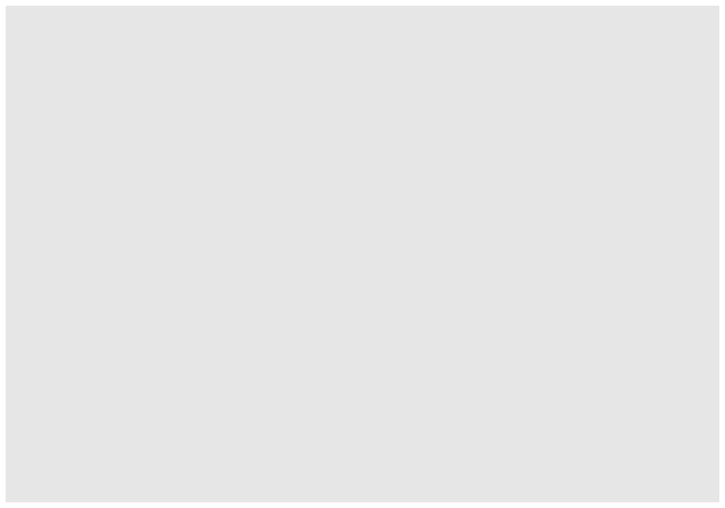

   ```r
   g
   ```

   That doesn’t work, because there is nothing to plot. We have to add a layer to it.
2. Adding a layer is done by adding a collection of geometric objects to it using one of the `geom_xxxx` functions. Each such function requires a *data set* and a *mapping* of columns in the data set to *aesthetics*. Let’s make some scatter-points: Meters as a function of Date:

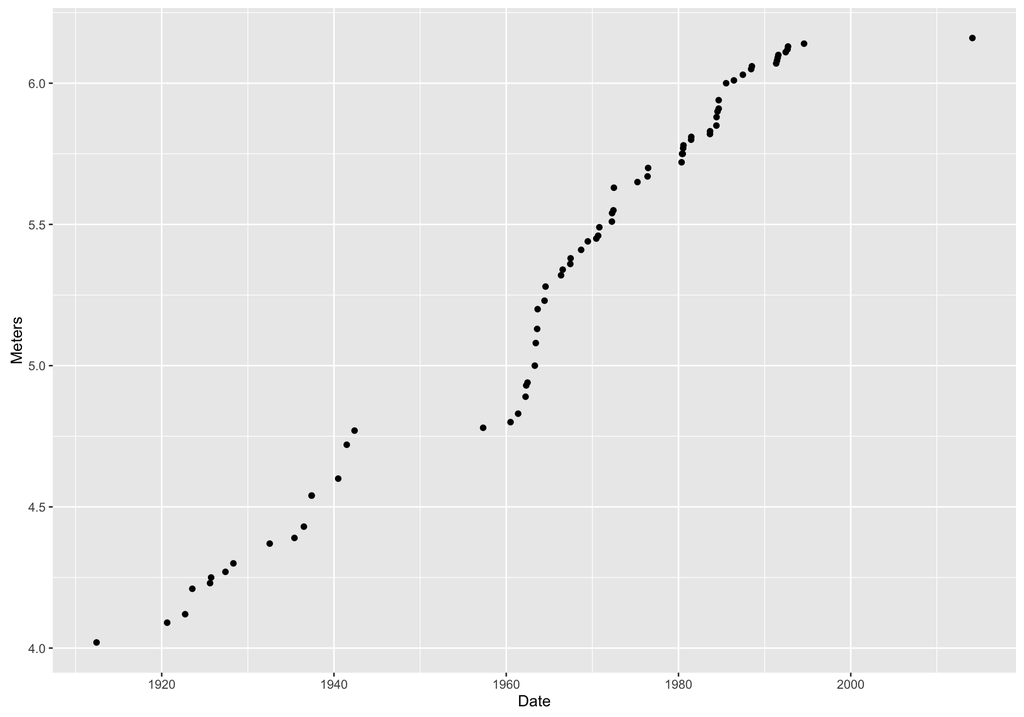

   ```r
   g2 <- g + geom_point(data = pv, mapping = aes(x = Date, y = Meters))
   g2
   ```

   Wow! That totally worked. Here are some interesting points about:

   ```r
   g2 <- g + geom_point(data = pv, mapping = aes(x = Date, y = Meters))
   g2
   ```

   1. You add layers by catenating them with `+`.
   2. the names of the columns don’t need to be quoted.
   3. when you map aesthestics you wrap them inside the `aes()` function
   4. the full object with all the layers is returned into `g2` and then we printed it (by typing `g2`). (we could have also just said `g + geom_point(data = pv, mapping = aes(x = Date, y = Meters))`)
   5. we didn’t have to do anything fancy to the dates…ggplot knew how to plot them. This is thanks to turning the dates into `lubridate` objects. (If you work with dates, get to know the lubridate package!)
3. I want to overlay a line on that…No problem! Add another layer:

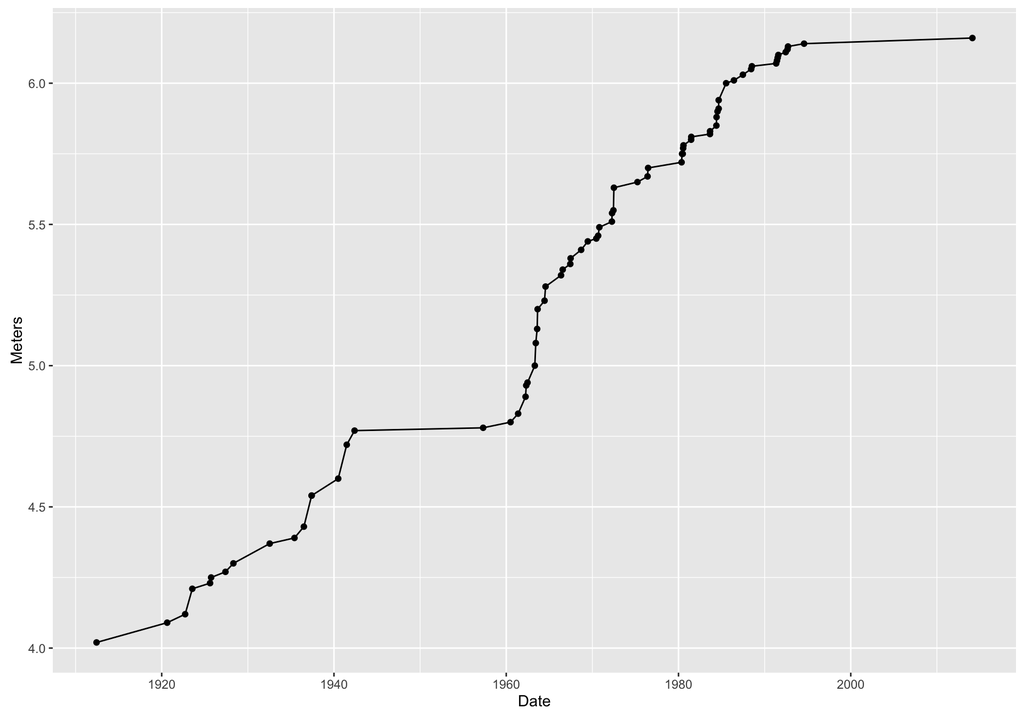

   ```r
   g3 <- g2 + geom_line(data = pv, mapping = aes(x = Date, y = Meters))
   g3
   ```

   That worked! We just added (literally, using a `+` sign!) another layer—one that had a line on it. BUT! what if I want to make that line blue?
4. Make the line blue. Note that you are giving the line an aesthetic property (the color blue), but you are not mapping that to any values in the data frame, **so** you don’t put that within the `aes()` function:

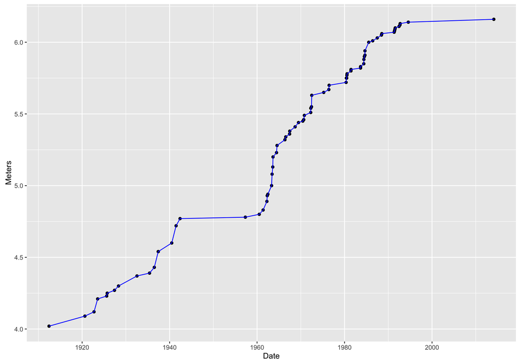

   ```r
   g4 <- g2 + geom_line(data = pv, mapping = aes(x = Date, y = Meters), color = "blue")
   g4
   ```

   That worked! Notice that we were able to put that new layer atop `g2` which we had stored previously.

### ggplot’s system of defaults

- Hey! I am really tired of typing `data = pv, mapping = aes(x = Date, y = Meters)` isn’t there some way around that?
- Yes! You can pass a default data frame and/or default mappings to the original `ggplot()` function. Then, if data and mappings are not specified in later layers, the defaults are used.
- Witness!

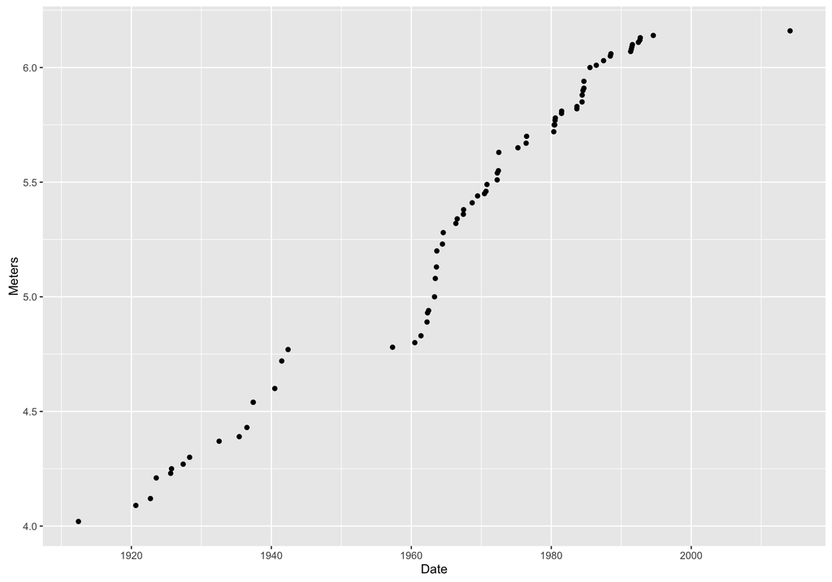

  ```r
  d <- ggplot(data = pv, aes(x = Date, y = Meters))  # this defines defaults
  d2 <- d + geom_point()  # add a layer with points
  d2  # print it
  ```

- Sick! Now we can add all sorts of fun layers as we see fit, each time, by invoking a `geom_xxx()` function.
- Let’s go totally crazy!
1. Establish plot base with defaults:

   ```r
   d <- ggplot(data = pv, aes(x = Date, y = Meters))
   ```

2. Add a transparent turquoise area along the back:

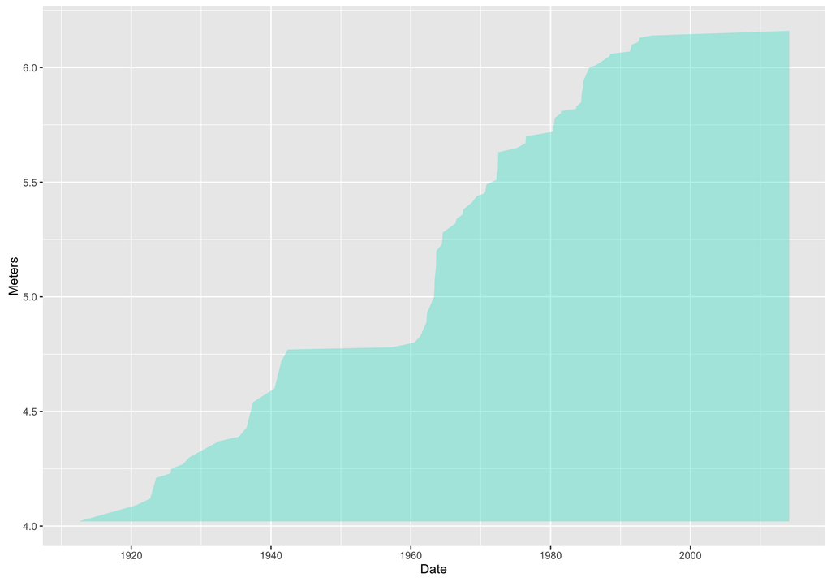

   ```r
   d2 <- d + geom_ribbon(aes(ymax = Meters), ymin = min(pv$Meters), alpha = 0.4, fill = "turquoise")
   d2
   ```

   Wow! I feel like transparency was never so easy in R base graphics!
3. Put a line along there too:

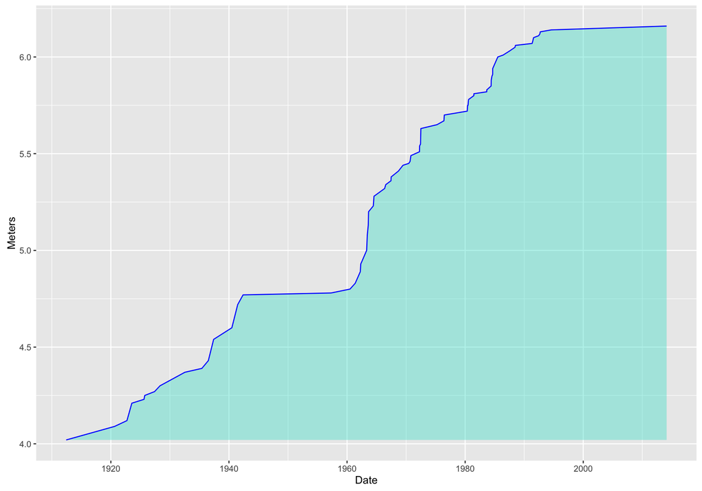

   ```r
   d3 <- d2 + geom_line(color = "blue")
   d3
   ```

4. Now add some small orange points:

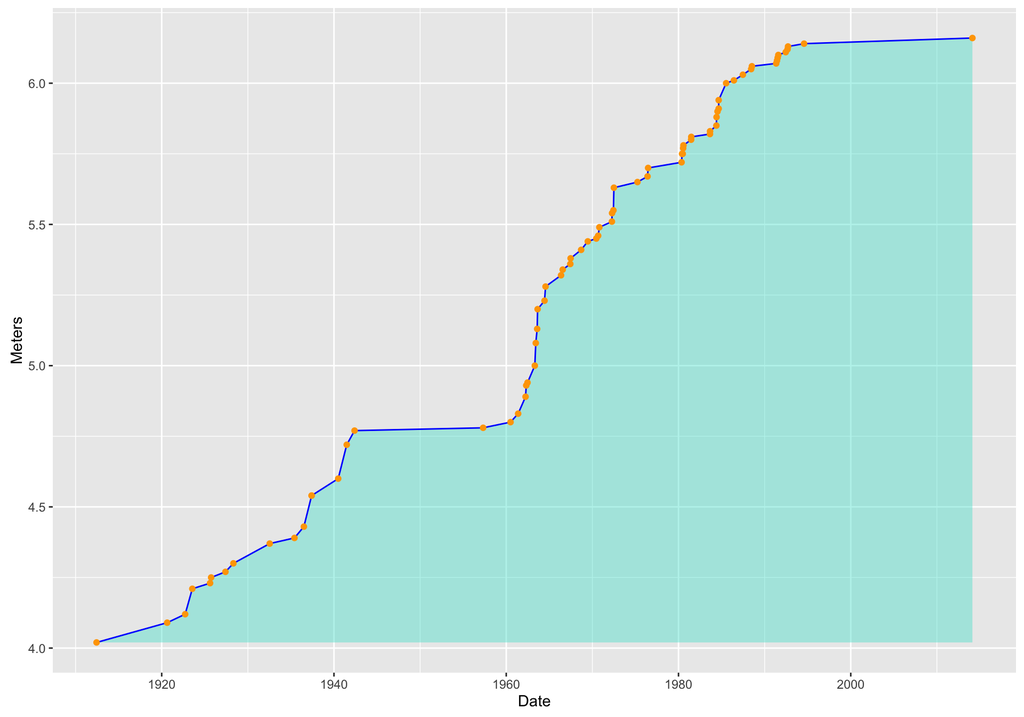

   ```r
   d4 <- d3 + geom_point(color = "orange")
   d4
   ```

5. Now, add “rugs” along the $x$ and $y$ axes that show the position of points, and in them, map *color* to *Nation*:

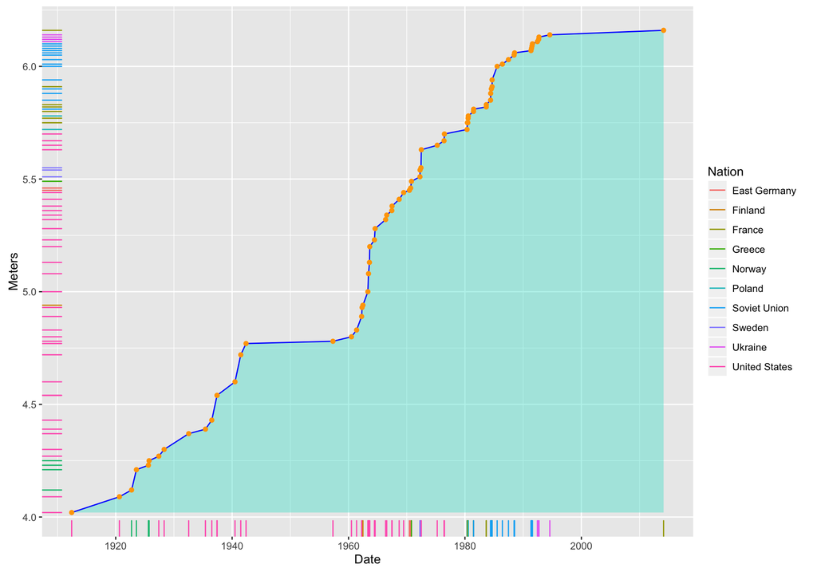

   ```r
   d5 <- d4 + geom_rug(sides = "bl", mapping = aes(color = Nation))
   d5
   ```

   - Note that we are using the `aes()` function to add the mapping of *color* to *Nation* within the `geom_rug()` function.
     - Note also that the legend was created automatically.
   - Wow! A legend is produced automatically, by default, and it looks pretty good. This doesn’t happen without an all-out wrestling match in R’s base graphics system.
- So, that was some fun playing around with the truly awesome ease with which you can build up complex and lovely graphics with ggplot.

### How many geoms are there?

- Quite a few. There is a good summary with little icons for each [here](http://docs.ggplot2.org/current/)
- Note that most geoms respond to the aesthetics of `x`, `y`, and `color` (or `fill`). And some have more (or other) aesthetics you can map values to.

### Getting even sillier

- Here is another plot I made while geeking out.
- I wanted to get a sense for how much individual athletes had improved since their first world record

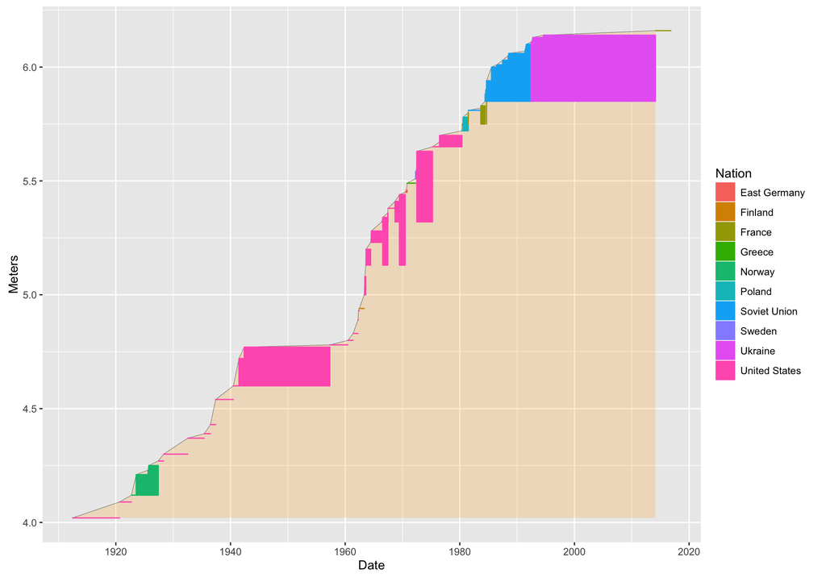

```r
# add a column for the date of first record for each athlete
tmp <- ddply(.data = pv, .variables = "Athlete", .fun = function(pv) min(pv$Meters))
rownames(tmp) <- tmp$Athlete
pv$FirstRecordMeters <- tmp[pv$Athlete, "V1"]

# now add a column for date of the next record:
pv$DateNext <- c(pv$Date[-1], ymd(today()))

bb <- ggplot(data = pv, mapping = aes(x = Date, y = Meters, color = Nation))  +
  geom_ribbon(aes(ymax = Meters, color = NULL), ymin = min(pv$Meters), alpha = 0.2, fill = "orange") +
  geom_line(color = "black", size = .1) +
  geom_rect(aes(xmin = Date,
                xmax = DateNext,
                ymin = FirstRecordMeters,
                ymax = Meters,
                fill = Nation
                ))
bb
```

I used `geom_rect()` to plot rectangles where the bottom edge is situated at the athlete’s lowest world record. Note how it required massaging some data into the data frame at the beginning.

## Playing on your own

It can be downright daunting learning `ggplot`. That is why I recommend you get a feel for it by playing with a sort of ggplot GUI developed by the guys who make the `mosaic` package.

Do this:

```r
library(ggplot2)
library(mosaic)
library(mosaicData)
library(lubridate)
mPlot(mtcars, system = "ggplot")
```

This will load the mtcars data set into moscaic’s ggplot “interactor”.

- Click the “gear” symbol in the upper left of the plot window and start fiddling!
  - Note that you only access a fraction of ggplot’s functionality this way, but it can still be informative.
- Hit the Show Expression button to see what commands create the resulting plot.
- Look for other data sets. Type `data()` to see a list of them. Or try

```r
data(package = "mosaicData")
```

Then consider:

```r
mPlot(Heightweight, system = "ggplot")
mPlot(Galton, system = "ggplot")
mPlot(Births78, system = "ggplot")
```

Or plug your own data frame in there.

- After seeing the expression, can you modify it to add more stuff, like:

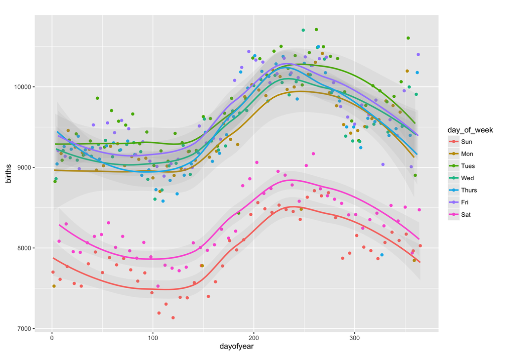

```r
Births78$day_of_week <- wday(ymd(Births78$date), label = TRUE)
ggplot(data=Births78, aes(x=dayofyear, y=births, color = day_of_week)) + geom_point()  + theme(legend.position="right") + labs(title="") + geom_smooth(method = "loess", alpha = .1)
```